# Read_recorded_packetInformation

### 6. Baseline with:

#### CTV update interval set to 5ms (equal to half RTT).

#### Counter size 2^8.

- Name: "TEST_EvX_MC5_C5D1_P1_I1_T1_1"
- Starts with 10 flows of gold and 10 flows silver.
  - MC5: m = 8, c = 2^8.
  - C5D1: CTV update interval = 5ms, reference delay = 2ms.
  - P1: Port shaping 1gig.
  - I1: No added flows.
  - T1: Test time = 30s

```
Average delay 1.57186 ms
Average throughput for 10 Silver flows between 0-30s: 229 Mbps
Average throughput for 10 Gold flows between 0-30s: 734 Mbps
```

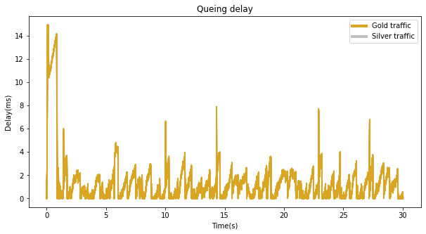

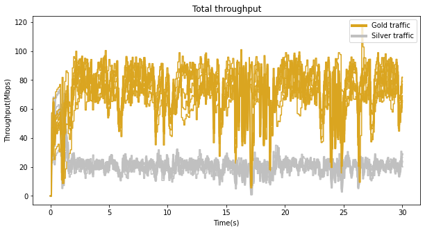

```python
name = "TEST_EvX_MC5_C5D1_P1_I1_T1_1"
save = False
Plots = StartPlot(name, save)
```

### 7. Standard PIE settings:

#### CTV update interval set to 32ms

#### Reference delay set to 2ms

#### α set to 0.125 and β set to 1.25.

- Name: "TEST_EvX_MC1_C3D1_P1_I1_T1_A2B2_1"
- Starts with 10 flows of gold and 10 flows silver.
  - MC1: m = 8, c = 2^10.
  - C3D1: CTV update interval = 32ms, reference delay = 2ms.
  - P1: Port shaping 1gig.
  - I1: No added flows.
  - T1: Test time = 30s
  - A2B2: α=0.125, β=1.25

```
Average delay 0.836148 ms
Average throughput for 10 Silver flows between 0-30s: 201 Mbps
Average throughput for 10 Gold flows between 0-30s: 649 Mbps
```

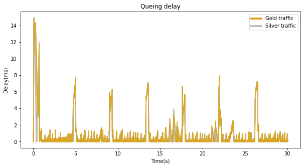

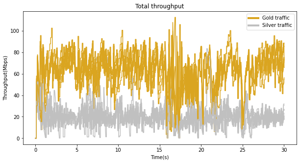

```python
name = "TEST_EvX_MC1_C3D1_P1_I1_T1_A2B2_1"
save = False
Plots = StartPlot(name, save)
```

### 8. Baseline with:

#### CTV update interval to 5ms (equal to RTT).

#### 5 flows of each type added each 10s.

- Name: "TEST_EvX_MC1_C5D1_P1_I4_T1_1"
- Starts with 5 flows of gold and 5 flows silver.
  - MC1: m = 8, c = 2^10.
  - C5D1: CTV update interval = 5ms, reference delay = 2ms.
  - P1: Port shaping 1gig.
  - I4: Add 5g and 5s each 10s
  - T1: Test time = 30s

```
Average delay 0.523222 ms
Average throughput for all Gold flows: 67.3003
Average throughput for all Silver flows: 23.885
```

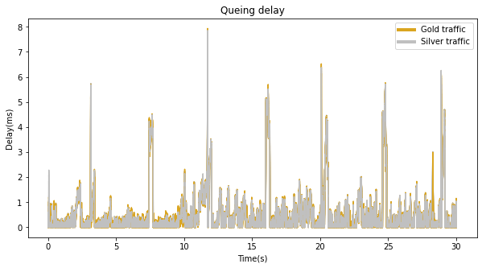

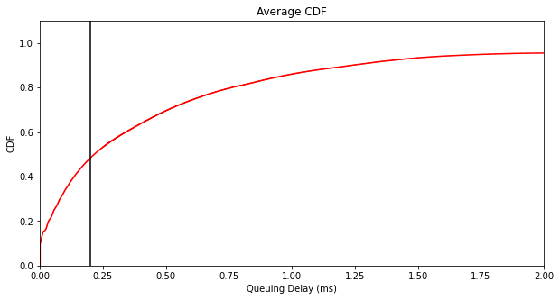

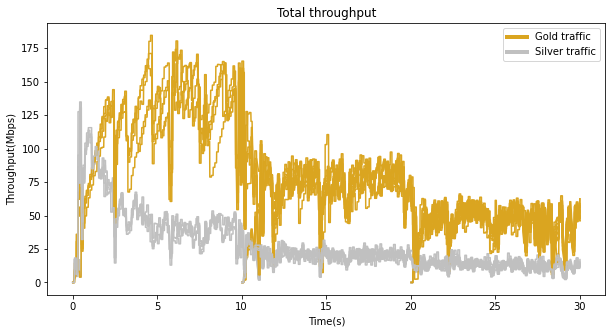

```python
name = "TEST_EvX_MC1_C5D1_P1_I4_T1_1"
save = False
Plots = StartPlot(name, save)
```

### 9. Baseline with:

#### CTV update interval 1µs

#### Reference delay 200µs

#### 5 flows of each type added each 10s.

- Name: "TEST_EvX_MC1_C2D2_P1_I4_T1_1"
- Starts with 5 flows of gold and 5 flows silver.
  - MC1: m = 8, c = 2^10.
  - C2D2: CTV update interval = 1µs, reference delay = 200µs.
  - P1: Port shaping 1gig.
  - I4: Add 5g and 5s each 10s
  - T1: Test time = 30s

```
Average delay 0.948721 ms
Average throughput for 5 Gold flows between 20-30s: 166 Mbps
Average throughput for 5 Gold flows between 10-30s: 227 Mbps
Average throughput for 5 Silver flows between 0-30s: 102 Mbps
Average throughput for 5 Silver flows between 10-30s: 62 Mbps
Average throughput for 5 Gold flows between 0-30s: 380 Mbps
Average throughput for 5 Silver flows between 20-30s: 48 Mbps
```

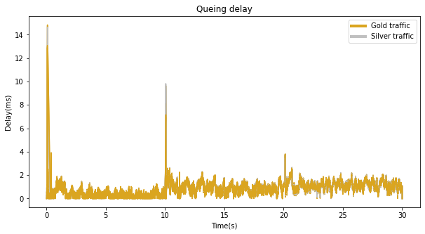

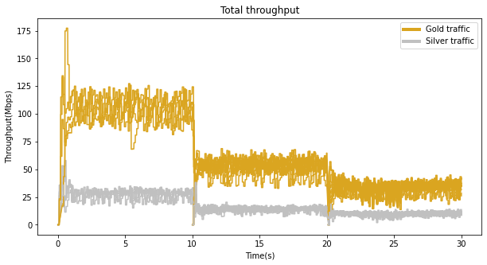

```python
name = "TEST_EvX_MC1_C2D2_P1_I4_T1_1"
save = False
Plots = StartPlot(name, save)
```

### 10. Baseline with:

#### CTV update interval set to 5ms(equal half RTT).

#### 5 flows of each type are added each 1s.

#### Counter size set to 2^14.

- ECDF update at m=8, c=2^14 updates slower than 1s.
- New flows are added with a 30 second duration until the 30s point.
- Name "TEST_EvX_MC6_C5D1_P1_I3_T1_1"
- Starts with 5 flows of gold and silver.
  - MC6: m = 8, c = 2^14.
  - C5D1: CTV update interval = 5ms, reference delay = 2ms.
  - P1: Port shaping 1gig.
  - I3: Add 5g and 5s every 1s.
  - T1: Test time = 30s

```
Average delay 0.549901 ms
Average throughput for Gold flows: 10.2093
Average throughput for Silver flows: 6.76543
```

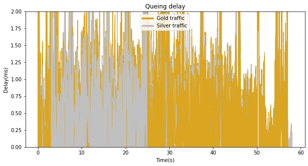

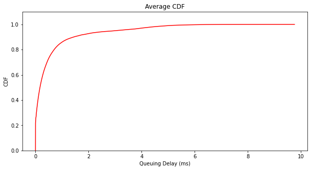

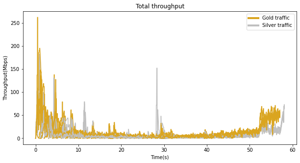

```python
name = "TEST_EvX_MC6_C5D1_P1_I3_T1_1"
save = False
Plots = StartPlot(name, save)
```

### 11. Baseline with:

#### CTV update interval equal to 1µs.

#### Reference delay set to 200µs.

#### 5 flows of each type are added each 1s.

- ECDF update at m=8, c=2^14 updates slower than 1s.
- New flows are added with a 30 second duration each 1s until the 30s point.
- Name: "TEST_EvX_MC6_C2D2_P1_I3_T1_1"
- Starts with 5 flows of gold and silver.
  - MC6: m = 8, c = 2^14.
  - C2D2: CTV update interval = 1µs, reference delay = 200µs
  - P1: Port shaping 1gig.
  - I3: Add 5g and 5s every 1s.
  - T1: Test time = 30s

```
Average delay 1.94191 ms
Average throughput for all Gold flows: 7.56834
Average throughput for all Silver flows: 4.12468
```

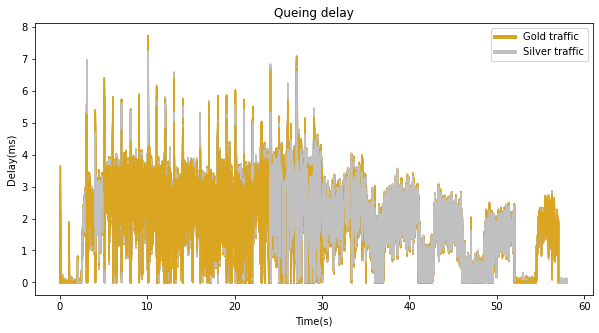

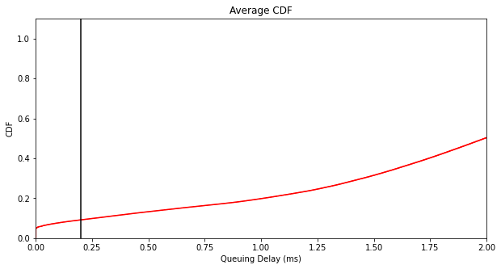

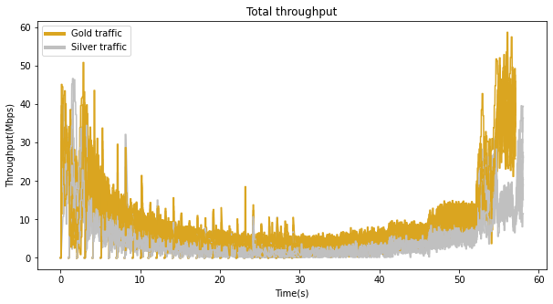

```python
name = "TEST_EvX_MC6_C2D2_P1_I3_T1_1"
save = False
Plots = StartPlot(name, save)
```

### 12. Baseline with:

#### CTV update interval set to 5ms (equal to half RTT).

#### 1 flow of each type are added each 50ms.

- ECDF update at m=8, c=2^10 updates slower than 50ms..
- New flows are added with a 10 second duration until the 10s point. Test stops at 12s.
- Name: "TEST_EvX_MC1_C5D1_P1_I2_T2_1"
- Starts with 5 flows of gold and silver.
  - MC1: m = 8, c = 2^10.
  - C5D1: CTV update interval = 5ms, reference delay = 2ms.
  - P1: Port shaping 1gig.
  - I2: Add 1g and 1s every 50ms.
  - T2: Test time = 10s

```
Average delay 0.54306 ms
Average throughput for all Gold flows: 4.68675
Average throughput for all Silver flows: 2.96282
```

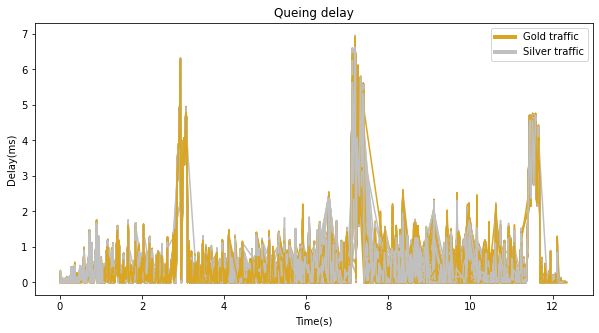

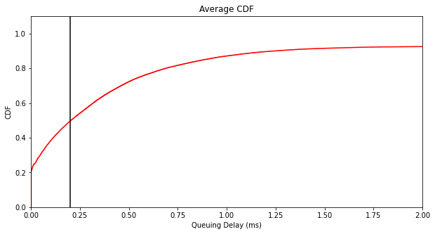

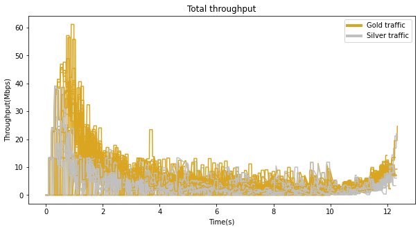

```python
name = "TEST_EvX_MC1_C5D1_P1_I2_T2_1"
save = False
Plots = StartPlot(name, save)
```

### 13. Baseline with:

#### no AQM active

- Name: "TEST_EvX_NoAqm_P1_I1_T1_1"
- 10 flows of gold and silver.
  - P1: Port shaping 1gig.
  - I1: No added flows.
  - T1: Test time = 30s

```
Average delay 13.8649 ms
Average throughput for 10 Gold flows between 0-30s: 519 Mbps
Average throughput for 10 Silver flows between 0-30s: 608 Mbps
```

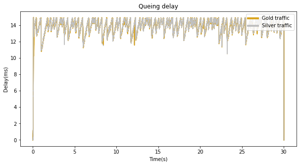

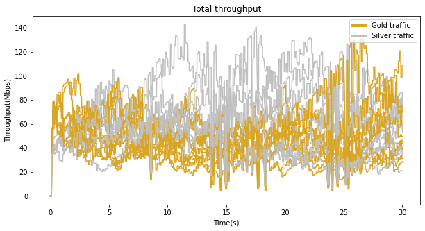

```python
name = "TEST_EvX_NoAqm_P1_I1_T1_1"
save = False
Plots = StartPlot(name, save)
```

### m = 13, c = 2^14, CTV update interval = 10µs.

- Name: "TEST_EvX_MC2_C1D1_P1_I1_T1_1"
- 10 flows of gold and silver.
  - MC2: m = 13, c = 2^14.
  - C1D1: CTV update interval = 10µs, reference delay = 2ms.
  - P1: Port shaping 1gig.
  - I1: No added flows.
  - T1: Test time = 30s.

```
Average delay 2.45933 ms
Average throughput for 10 Silver: 206 Mbps
Average throughput for 10 Gold: 662 Mbps
```

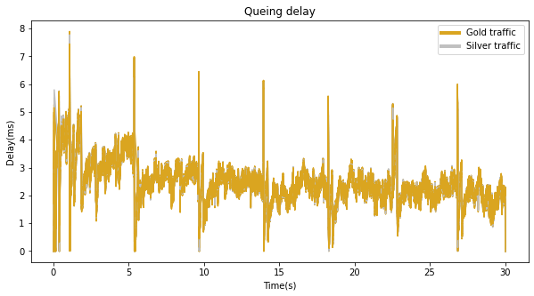

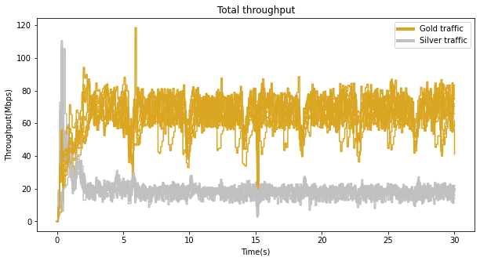

```python
name = "TEST_EvX_MC2_C1D1_P1_I1_T1_1"
save = False
Plots = StartPlot(name, save)
```

## Evaluation

### 2. The following tests will evaluate packet values from the marker.

- The following assumptions are made:
  - m represents table size.
  - c represents counter size.
  - The ECDF update timer in the Control Plane is set to 0.
  - α is set to 0.3125 and β is set to 3.125, unless otherwise specified.

The setting of the following tests are the same for the respective number as for evaluation 1, e.g. test 8 below is the same as test 8 above. These tests show the packet value distribution of packets that has successfully been passed through the switch.

### 1. Baseline test.

- Name: "TEST_Ev2_MC1_C1D1_P1_I1_T1_1"
- Starts with 10 flows of gold and 10 flows silver.
  - MC1: m = 8, c = 2^10.
  - C1D1: CTV update interval = 10µs, reference delay = 2ms.
  - P1: Port shaping 1gig.
  - I1: No added flows.
  - T1: Test time = 30s

```
Percent of Gold packets: 74.4358%
Percent of Silver packets: 25.5642%
Mean of the marking for 10 Silver marking 0-30s: 31177.2, median: 31249.4
Mean of the marking for 10 Gold marking 0-30s: 31295.8, median: 31283.7
```

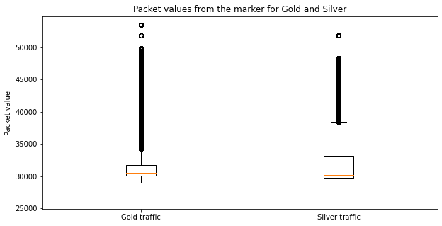

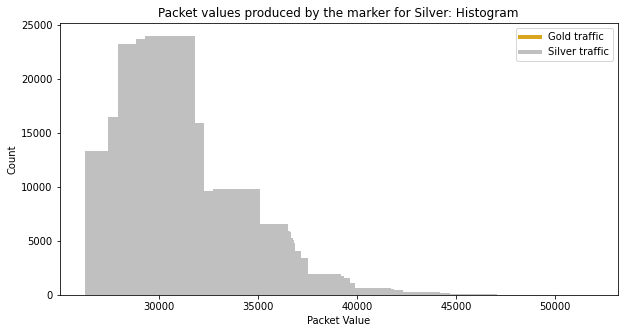

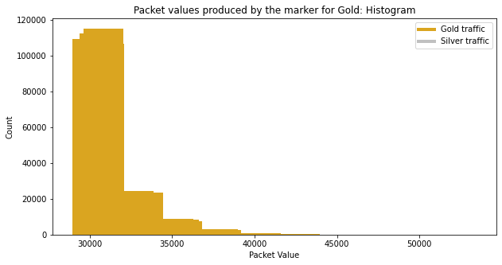

```python
name = "TEST_Ev2_MC1_C1D1_P1_I1_T1_1"
save = False
Plots = StartPlot(name, save)
```

### 8. Baseline with:

#### CTV update interval to 5ms (equal to RTT).

#### 5 flows of each type added each 10s.

- Name: "TEST_Ev2_MC1_C5D1_P1_I4_T1_1"
- Starts with 5 flows of gold and 5 flows silver.
  - MC1: m = 8, c = 2^10.
  - C5D1: CTV update interval = 5ms, reference delay = 2ms.
  - P1: Port shaping 1gig.
  - I4: Add 5g and 5s each 10s
  - T1: Test time = 30s

```
Percent of Gold packets: 70.8443%
Percent of Silver packets: 29.1557%
Mean of the marking for 5 Silver marking 0-29s: 28994.4, median: 28923.8
Mean of the marking for 5 Silver marking 10-29s: 31982.4, median: 31960.3
Mean of the marking for 5 Gold marking 10-29s: 31420.6, median: 31438
Mean of the marking for 5 Gold marking 20-29s: 32038.6, median: 32016
Mean of the marking for 5 Gold marking 0-29s: 30654.4, median: 30667.9
Mean of the marking for 5 Silver marking 20-29s: 32967.8, median: 32967.8
```

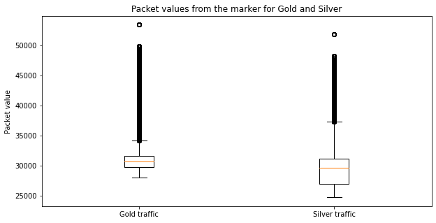

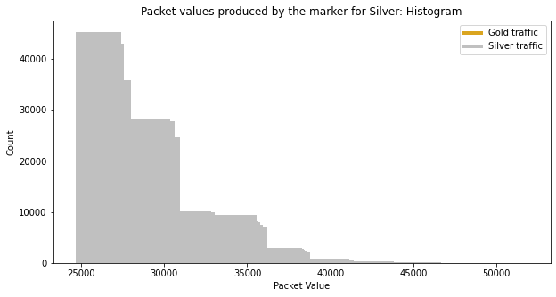

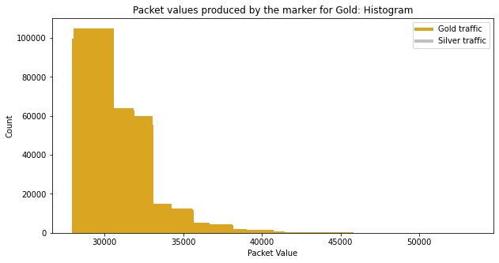

```python
name = "TEST_Ev2_MC1_C5D1_P1_I4_T1_1"
save = False
Plots = StartPlot(name, save)
```

### 9. Baseline with:

#### CTV update interval 1µs

#### Reference delay 200µs

#### 5 flows of each type added each 10s.

- Name: "TEST_Ev2_MC1_C2D2_P1_I4_T1_1"
- Starts with 5 flows of gold and 5 flows silver.
  - MC1: m = 8, c = 2^10.
  - C2D2: CTV update interval = 1µs, reference delay = 200µs.
  - P1: Port shaping 1gig.
  - I4: Add 5g and 5s each 10s
  - T1: Test time = 30s

```
Percent of Gold packets: 77.6672%
Percent of Silver packets: 22.3328%
Mean of the marking for 5 Gold marking 20-30s: 32913.6, median: 32930.2
Mean of the marking for 5 Silver marking 0-30s: 31909.8, median: 31886.7
Mean of the marking for 5 Gold marking 10-30s: 32267.6, median: 32266.5
Mean of the marking for 5 Silver marking 20-30s: 34525.2, median: 34523.8
Mean of the marking for 5 Gold marking 0-30s: 31210.4, median: 31241.3
Mean of the marking for 5 Silver marking 10-30s: 33592.8, median: 33598.2
```

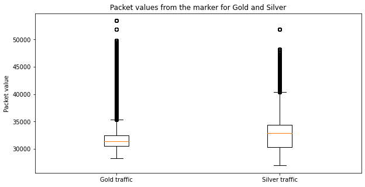

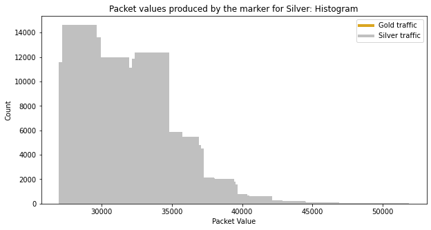

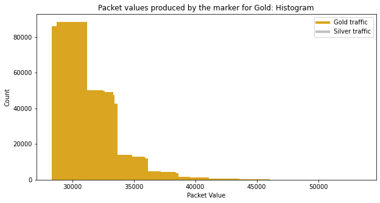

```python
name = "TEST_Ev2_MC1_C2D2_P1_I4_T1_1"
save = False
Plots = StartPlot(name, save)
```